# 축구 데이터 - 1. 순위가 높은팀과 낮은팀 끼리의 승패

```python
import pandas as pd

df = pd.DataFrame({'Team_Name':["맨시티", "맨유","리버풀","첼시","레스터","웨스트햄","토트넘","아스널",
                               "리즈","에버튼","아스톤빌라","뉴캐슬","울버햄튼","크팰","소튼",
                               "브라이튼","번리","풀럼","웨스트브롬","셰필드"],
                   'Normal':[24,16,17,16,19,21,20,20,19,14,18,17,16,19,16,12,17,20,20,27],
                   'Exp':[7,9,11,11,12,8,9,10,13,15,11,11,11,9,14,11,11,4,6,7],
                   'Draw':[5,11,9,10,6,8,8,7,5,8,7,9,9,8,7,14,9,13,11,2],
                   'Same_Level':[1,1,0,0,0,0,0,0,0,0,1,0,1,1,0,0,0,0,0,1]
                    })
df['Round'] = df['Normal'] + df['Exp'] + df['Draw'] + df['Same_Level']
df['Normal_Rate'] = df['Normal'] / df['Round']
df['Exp_and_Draw_Rate'] = ( df['Exp'] + df['Draw'] ) / df['Round']
df
```

|  | Team_Name | Normal | Exp | Draw | Same_Level | Round | Normal_Rate | Exp_and_Draw_Rate |
| --- | --- | --- | --- | --- | --- | --- | --- | --- |
| 0 | 맨시티 | 24 | 7 | 5 | 1 | 37 | 0.648649 | 0.324324 |
| 1 | 맨유 | 16 | 9 | 11 | 1 | 37 | 0.432432 | 0.540541 |
| 2 | 리버풀 | 17 | 11 | 9 | 0 | 37 | 0.459459 | 0.540541 |
| 3 | 첼시 | 16 | 11 | 10 | 0 | 37 | 0.432432 | 0.567568 |
| 4 | 레스터 | 19 | 12 | 6 | 0 | 37 | 0.513514 | 0.486486 |
| 5 | 웨스트햄 | 21 | 8 | 8 | 0 | 37 | 0.567568 | 0.432432 |
| 6 | 토트넘 | 20 | 9 | 8 | 0 | 37 | 0.540541 | 0.459459 |
| 7 | 아스널 | 20 | 10 | 7 | 0 | 37 | 0.540541 | 0.459459 |
| 8 | 리즈 | 19 | 13 | 5 | 0 | 37 | 0.513514 | 0.486486 |
| 9 | 에버튼 | 14 | 15 | 8 | 0 | 37 | 0.378378 | 0.621622 |
| 10 | 아스톤빌라 | 18 | 11 | 7 | 1 | 37 | 0.486486 | 0.486486 |
| 11 | 뉴캐슬 | 17 | 11 | 9 | 0 | 37 | 0.459459 | 0.540541 |
| 12 | 울버햄튼 | 16 | 11 | 9 | 1 | 37 | 0.432432 | 0.540541 |
| 13 | 크팰 | 19 | 9 | 8 | 1 | 37 | 0.513514 | 0.459459 |
| 14 | 소튼 | 16 | 14 | 7 | 0 | 37 | 0.432432 | 0.567568 |
| 15 | 브라이튼 | 12 | 11 | 14 | 0 | 37 | 0.324324 | 0.675676 |
| 16 | 번리 | 17 | 11 | 9 | 0 | 37 | 0.459459 | 0.540541 |
| 17 | 풀럼 | 20 | 4 | 13 | 0 | 37 | 0.540541 | 0.459459 |
| 18 | 웨스트브롬 | 20 | 6 | 11 | 0 | 37 | 0.540541 | 0.459459 |
| 19 | 셰필드 | 27 | 7 | 2 | 1 | 37 | 0.729730 | 0.243243 |

- 순위가 높은 팀과 낮은 팀의 normal , exp , draw , same_level에 대한 데이터 프레임
- normal_rate 의 경우 각 팀별로 얼마나 normal한 경우가 나왔는지 알아볼 수 있도록 normal 빈도 / 전체 라운드수
- exp_and_draw_rate 의 경우 각 팀별로 normal 하지 않은 경우가 얼마나 나왔는지 알아볼 수 있도록 함
- draw의 경우 normal한 상황으로 볼 수도 있고 , exp한 상황으로 볼 수도 있기에 분리해서 처리함

```python
df_sort_by_rate = df.sort_values(by=['Normal_Rate'], axis=0, ascending=False)
df_sort_by_rate
```

|  | Team_Name | Normal | Exp | Draw | Same_Level | Round | Normal_Rate | Exp_and_Draw_Rate |
| --- | --- | --- | --- | --- | --- | --- | --- | --- |
| 19 | 셰필드 | 27 | 7 | 2 | 1 | 37 | 0.729730 | 0.243243 |
| 0 | 맨시티 | 24 | 7 | 5 | 1 | 37 | 0.648649 | 0.324324 |
| 5 | 웨스트햄 | 21 | 8 | 8 | 0 | 37 | 0.567568 | 0.432432 |
| 6 | 토트넘 | 20 | 9 | 8 | 0 | 37 | 0.540541 | 0.459459 |
| 7 | 아스널 | 20 | 10 | 7 | 0 | 37 | 0.540541 | 0.459459 |
| 18 | 웨스트브롬 | 20 | 6 | 11 | 0 | 37 | 0.540541 | 0.459459 |
| 17 | 풀럼 | 20 | 4 | 13 | 0 | 37 | 0.540541 | 0.459459 |
| 13 | 크팰 | 19 | 9 | 8 | 1 | 37 | 0.513514 | 0.459459 |
| 4 | 레스터 | 19 | 12 | 6 | 0 | 37 | 0.513514 | 0.486486 |
| 8 | 리즈 | 19 | 13 | 5 | 0 | 37 | 0.513514 | 0.486486 |
| 10 | 아스톤빌라 | 18 | 11 | 7 | 1 | 37 | 0.486486 | 0.486486 |
| 16 | 번리 | 17 | 11 | 9 | 0 | 37 | 0.459459 | 0.540541 |
| 2 | 리버풀 | 17 | 11 | 9 | 0 | 37 | 0.459459 | 0.540541 |
| 11 | 뉴캐슬 | 17 | 11 | 9 | 0 | 37 | 0.459459 | 0.540541 |
| 12 | 울버햄튼 | 16 | 11 | 9 | 1 | 37 | 0.432432 | 0.540541 |
| 14 | 소튼 | 16 | 14 | 7 | 0 | 37 | 0.432432 | 0.567568 |
| 3 | 첼시 | 16 | 11 | 10 | 0 | 37 | 0.432432 | 0.567568 |
| 1 | 맨유 | 16 | 9 | 11 | 1 | 37 | 0.432432 | 0.540541 |
| 9 | 에버튼 | 14 | 15 | 8 | 0 | 37 | 0.378378 | 0.621622 |
| 15 | 브라이튼 | 12 | 11 | 14 | 0 | 37 | 0.324324 | 0.675676 |

df_sort_by_rate 의 경우 , normal_rate 순으로 정렬한 데이터 프레임이다.  
각 팀별로 각각 0.73 ~ 0.32 사이의 rate를 가지는 것을 볼 수 있다.

```python
df_sort_by_rate2 = df.sort_values(by=['Exp_and_Draw_Rate'], axis=0, ascending=False)
df_sort_by_rate2
```

|  | Team_Name | Normal | Exp | Draw | Same_Level | Round | Normal_Rate | Exp_and_Draw_Rate |
| --- | --- | --- | --- | --- | --- | --- | --- | --- |
| 15 | 브라이튼 | 12 | 11 | 14 | 0 | 37 | 0.324324 | 0.675676 |
| 9 | 에버튼 | 14 | 15 | 8 | 0 | 37 | 0.378378 | 0.621622 |
| 3 | 첼시 | 16 | 11 | 10 | 0 | 37 | 0.432432 | 0.567568 |
| 14 | 소튼 | 16 | 14 | 7 | 0 | 37 | 0.432432 | 0.567568 |
| 1 | 맨유 | 16 | 9 | 11 | 1 | 37 | 0.432432 | 0.540541 |
| 2 | 리버풀 | 17 | 11 | 9 | 0 | 37 | 0.459459 | 0.540541 |
| 16 | 번리 | 17 | 11 | 9 | 0 | 37 | 0.459459 | 0.540541 |
| 12 | 울버햄튼 | 16 | 11 | 9 | 1 | 37 | 0.432432 | 0.540541 |
| 11 | 뉴캐슬 | 17 | 11 | 9 | 0 | 37 | 0.459459 | 0.540541 |
| 10 | 아스톤빌라 | 18 | 11 | 7 | 1 | 37 | 0.486486 | 0.486486 |
| 8 | 리즈 | 19 | 13 | 5 | 0 | 37 | 0.513514 | 0.486486 |
| 4 | 레스터 | 19 | 12 | 6 | 0 | 37 | 0.513514 | 0.486486 |
| 18 | 웨스트브롬 | 20 | 6 | 11 | 0 | 37 | 0.540541 | 0.459459 |
| 7 | 아스널 | 20 | 10 | 7 | 0 | 37 | 0.540541 | 0.459459 |
| 13 | 크팰 | 19 | 9 | 8 | 1 | 37 | 0.513514 | 0.459459 |
| 6 | 토트넘 | 20 | 9 | 8 | 0 | 37 | 0.540541 | 0.459459 |
| 17 | 풀럼 | 20 | 4 | 13 | 0 | 37 | 0.540541 | 0.459459 |
| 5 | 웨스트햄 | 21 | 8 | 8 | 0 | 37 | 0.567568 | 0.432432 |
| 0 | 맨시티 | 24 | 7 | 5 | 1 | 37 | 0.648649 | 0.324324 |
| 19 | 셰필드 | 27 | 7 | 2 | 1 | 37 | 0.729730 | 0.243243 |

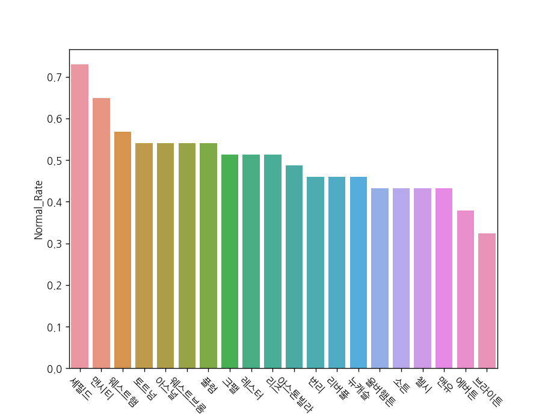

```python
import matplotlib.pyplot as plt
import seaborn as sns
%matplotlib notebook

plt.xticks(rotation = -45)
sns.barplot(data=df_sort_by_rate, x="Team_Name", y="Normal_Rate")
plt.show()
```

## normal_rate 가 높은 팀

- 해당 시즌의 1등 팀인 맨시티와 20등인 셰필드가 가장 normal_rate가 높음을 볼 수 있다.
- 두팀 모두 1등과 20등을 유지한 기간이 높고 , 해당 등수에 따라서 normal_case의 승리와 패배를 많이 하였기에 normal_rate가 높다
- normal_rate 상위 팀들을 살펴보면 웨스트햄 , 토트넘 , 아스널 이다.
- 3팀 모두 0.54 ~ 0.56 사이의 비율을 보여주고 있다.

## normal_rate 가 낮은 팀

- normal_rate가 낮은 하위 두 팀은 브라이튼 , 에버튼 이다.
- 브라이튼의 경우 normal_rate가 특히 낮은데 , 약 0.32로 20팀들중 가장 낮다.
- 브라이튼의 경우 0.32 이므로 약 12 경기만 순위에 알맞은 결과를 내었다.
- 브라이튼의 나머지 25 경기는 본인 순위보다 낮은 팀에게 무,패를 기록하거나 , 본인 순위보다 높은 팀에게 승리한 경기이다.

```python
df["Normal_Rate"].mean()
```

```
0.49729729729729727
```

normal_rate의 평균은 약 0.497 로 절반에 못미치게 나왔다.  
EPL 20/21 시즌의 경우 순위가 높은 팀이 순위가 낮은 팀을 이긴 경우는 전체에 비해 약 49.7% 이다.

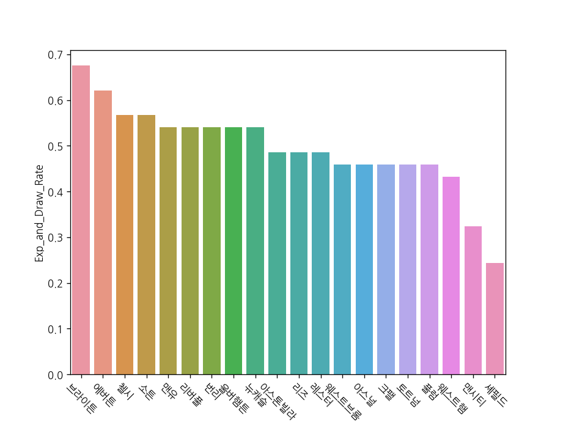

```python
import matplotlib.pyplot as plt
import seaborn as sns
%matplotlib notebook

plt.xticks(rotation = -45)
sns.barplot(data=df_sort_by_rate2, x="Team_Name", y="Exp_and_Draw_Rate")
plt.show()
```

```python
df["Exp_and_Draw_Rate"].mean()

#0.49 -> 이역시 49퍼센트 정도의 확률
```

```
0.49459459459459476
```

## Exp_and_Draw_rate 의 경우

- 위의 exp_and_draw_rate의 경우도 normal_rate와 거의 흡사한 모습을 보인다.
- same_level 즉 , 같은 순위의 팀들끼리의 경기가 normal_rate , exp_and_draw_rate 에서 모두 제외되었으므로 normal_rate 의 순위와 조금 다른 것을 제외하면 normal_rate의 결과와 거의 같다.

exp_and_draw_rate의 평균은 약 0.494로 normal_rate와 비슷하게 나왔다.  
EPL 20/21 시즌의 경우 순위가 높은팀이 순위가 낮은 팀을 이기지 못한 경우는 전체에 비해 약 49.4% 이다.